# zadanie5_bagin.R

samuelbagin

2026-11-04

# zadanie 5

samuel bagin

```r
library(ggplot2)
library(viridisLite)
library(nortest)
library(latex2exp)
library(tseries)
alfa <- 0.05
velkosti <- seq(20, 300, 20)
opakovania <- 1000
ciel <- 0.95
farby <- viridis(4, end = 0.8)
set.seed(2026)
```

# 1. rozdelenia a metodika

$h_0: x \sim \mathrm{n}(\mu,\sigma^2)$, kde $\mu$ a $\sigma^2$ su nezname. alternativa $h_1$: rozdelenie nie je normalne. testujeme na hladine $\alpha = 0{,}05$ a $h_0$ zamietame pri $p < \alpha$. nezamietnutie $h_0$ nie je dokaz normality, najma pri malych vzorkach.

```r
generatory <- list(
  rovnomerne = function(n) runif(n, min = 0, max = 1),
  cauchyho = function(n) rcauchy(n, location = 0, scale = 1),
  exponencialne = function(n) rexp(n, rate = 1)
)
```

pre rozdelenia $\mathrm{u}(0,1)$, $\mathrm{c}(0,1)$ a $\mathrm{exp}(1)$ pri $n \in \{20,40,\ldots,300\}$ generujeme $b = 1000$ nezavislych vzoriek. vsetky styri testy dostanu rovnaku vzorku. $p$-hodnoty prveho opakovania ukazuju jeden priebeh a podiel zamietnuti odhaduje silu testu. pre rozne velkosti generujeme nove vzorky, nejde o postupne rozsirovanie tej istej vzorky.

# 2. testy normality

SW porovnava usporiadane hodnoty s normalnymi kvantilmi, AD porovnava distribucne funkcie s vacsou vahou chvostov. lill sleduje najvacsi rozdiel distribucnych funkcii a zohladnuje odhad priemeru a rozptylu zo vzorky. jb hodnoti odchylku sikmosti $s$ od $0$ a spicatosti $k$ od $3$.

```r
testy_normality <- function(x) {
  c(sw = shapiro.test(x)$p.value,
    ad = ad.test(x)$p.value,
    jb = tseries::jarque.bera.test(x)$p.value,
    lill = lillie.test(x)$p.value)
}
```

$\bar{x} = \frac{1}{n}\sum_{i=1}^{n}x_i$, $m_r = \frac{1}{n}\sum_{i=1}^{n}(x_i - \bar{x})^r$, $s = \frac{m_3}{m_2^{3/2}}$ a $k = \frac{m_4}{m_2^2}$. $\mathrm{jb} = \frac{n}{6}\left(s^2 + \frac{(k - 3)^2}{4}\right)$ ma pri $h_0$ asymptoticky rozdelenie $\chi^2_2$. preto je $p$-hodnota jb pri malych vzorkach iba priblizna.

# 3. simulacia a diagnosticke grafy

prvu vzorku pre kazde rozdelenie a velkost ulozime aj pre grafy, aby sme zobrazovali tie iste data, ktore testujeme.

```r
simulacie <- setNames(lapply(names(generatory), function(rozdelenie) {
  setNames(lapply(velkosti, function(n) {
    vzorka <- generatory[[rozdelenie]](n)
    p <- cbind(testy_normality(vzorka),
               replicate(opakovania - 1, testy_normality(generatory[[rozdelenie]](n))))
    list(vzorka = vzorka,
         vysledky = data.frame(rozdelenie = rozdelenie, n = n, test = rownames(p),
                               p = p[, 1], sila = rowMeans(p < alfa), row.names = NULL))
  }), as.character(velkosti))
}), names(generatory))

vysledky <- do.call(rbind, lapply(simulacie, function(rozdelenie) {
  do.call(rbind, lapply(rozdelenie, function(simulacia) simulacia$vysledky))
}))

vysledky$rozdelenie <- factor(vysledky$rozdelenie, levels = names(generatory))
vysledky$test <- factor(vysledky$test, levels = c("sw", "ad", "jb", "lill"))
rownames(vysledky) <- NULL

popisy_rozdeleni <- setNames(as.character(TeX(c(
  "rovnomerne $u(0,1)$", "cauchyho $c(0,1)$", "exponencialne $\\exp(1)$"
))), levels(vysledky$rozdelenie))
popisy_testov <- TeX(c("$sw$", "$ad$", "$jb$", "$lill$"))

stopifnot(nrow(vysledky) == 180, !anyNA(vysledky),
          all(vysledky$p >= 0 & vysledky$p <= 1),
          all(vysledky$sila >= 0 & vysledky$sila <= 1))
```

## normalne q-q grafy ako na cviceni

riadky zodpovedaju rozdeleniam a stlpce velkostiam $n = 20,100,300$. pri normalnom rozdeleni by body priblizne sledovali referencnu priamku. systematicke zakrivenie alebo odchylky v chvostoch upozornuju na nenormalitu.

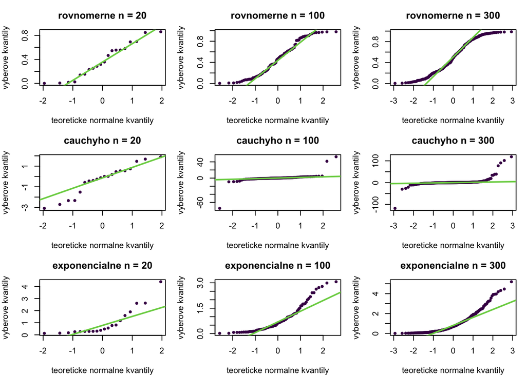

```r
vykresli_qq <- function() {
  povodne <- par(mfrow = c(3, 3), mar = c(4, 4, 3, 1))
  on.exit(par(povodne))
  for (rozdelenie in names(simulacie)) {
    for (n in c(20, 100, 300)) {
      x <- simulacie[[rozdelenie]][[as.character(n)]]$vzorka
      qqnorm(x, main = paste(rozdelenie, "n =", n),
             xlab = "teoreticke normalne kvantily", ylab = "vyberove kvantily",
             pch = 19, cex = 0.6, col = farby[1])
      qqline(x, col = farby[4], lwd = 2)
    }
  }
}
vykresli_qq()
```

## histogramy a krabicove grafy ako na cviceni

pre $n = 100$ doplname pohlad na tvar rozdelenia, symetriu a extremne hodnoty. rozsahy osi sa prisposobuju jednotlivym rozdeleniam. boxplot sam osebe normalitu nepotvrdzuje ani nevyvracia, doplna q-q graf a testy.

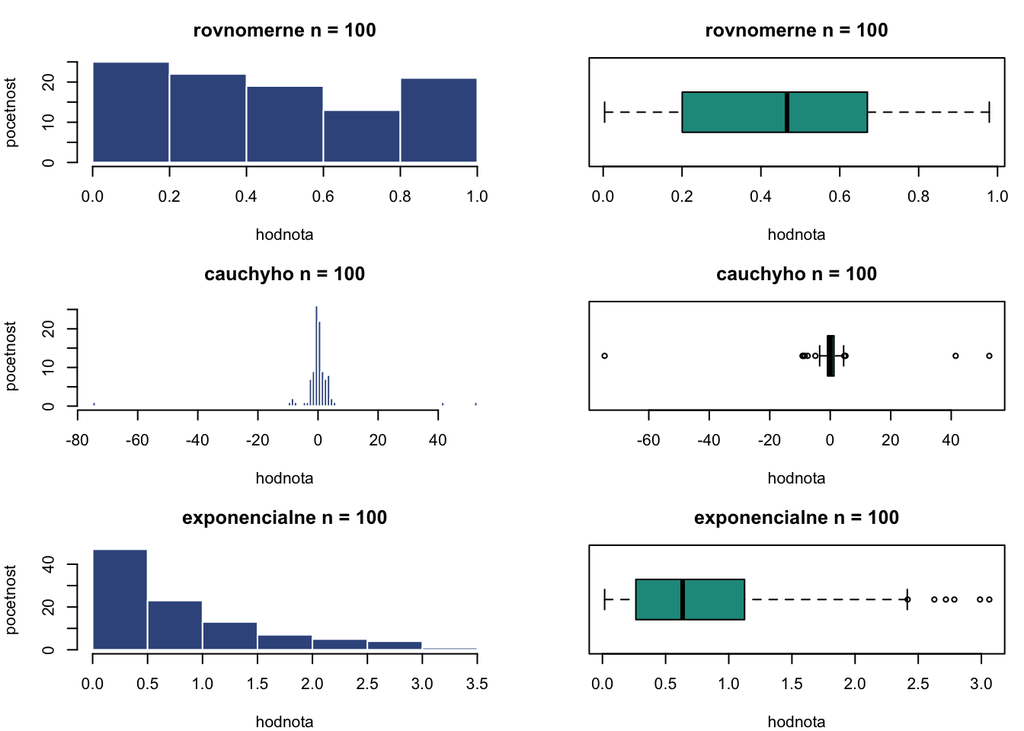

```r
vykresli_tvary <- function() {
  povodne <- par(mfrow = c(3, 2), mar = c(4, 4, 3, 1))
  on.exit(par(povodne))
  for (rozdelenie in names(simulacie)) {
    x <- simulacie[[rozdelenie]][["100"]]$vzorka
    hist(x, breaks = "FD", main = paste(rozdelenie, "n = 100"),
         xlab = "hodnota", ylab = "pocetnost", col = farby[2], border = "white")
    boxplot(x, horizontal = TRUE, main = paste(rozdelenie, "n = 100"),
            xlab = "hodnota", col = farby[3])
  }
}
vykresli_tvary()
```

# 4. vyvoj $p$-hodnot

```r
p_hodnoty <- reshape(vysledky[c("rozdelenie", "n", "test", "p")],
                     idvar = c("rozdelenie", "n"), timevar = "test", direction = "wide")
rownames(p_hodnoty) <- NULL
print(p_hodnoty, row.names = FALSE)
```

```
##     rozdelenie   n         p.sw         p.ad         p.jb        p.lill
##     rovnomerne  20 2.174525e-01 3.934338e-01 5.529820e-01  5.938087e-01
##     rovnomerne  40 3.090868e-03 1.243465e-03 1.546448e-01  1.812900e-02
##     rovnomerne  60 1.245739e-02 3.017583e-02 1.500984e-01  1.602531e-01
##     rovnomerne  80 6.783161e-03 2.021724e-02 9.460272e-02  1.624431e-01
##     rovnomerne 100 3.249264e-04 1.338996e-03 4.639552e-02  4.737161e-02
##     rovnomerne 120 6.187404e-05 8.973281e-05 1.892304e-02  2.659920e-03
##     rovnomerne 140 9.697895e-06 8.960648e-06 7.305198e-03  9.246505e-03
##     rovnomerne 160 1.243217e-04 2.028450e-04 1.114838e-02  2.127255e-02
##     rovnomerne 180 7.708669e-06 9.237722e-06 3.562206e-03  3.258360e-03
##     rovnomerne 200 3.287023e-06 3.215481e-06 1.998591e-03  5.142836e-03
##     rovnomerne 220 2.608614e-07 1.334116e-07 7.192467e-04  1.706872e-03
##     rovnomerne 240 1.546971e-06 1.338640e-05 1.927937e-03  2.266272e-02
##     rovnomerne 260 2.173791e-07 2.440611e-07 5.236395e-04  6.551561e-03
##     rovnomerne 280 7.558027e-08 2.600305e-08 2.015128e-04  1.018949e-03
##     rovnomerne 300 1.595384e-08 3.410453e-10 7.168973e-05  4.163710e-05
##       cauchyho  20 1.983857e-01 1.391165e-01 5.842226e-01  1.092216e-01
##       cauchyho  40 5.384671e-12 3.700000e-24 0.000000e+00  7.535076e-19
##       cauchyho  60 9.588921e-09 7.070877e-13 0.000000e+00  7.507352e-10
##       cauchyho  80 3.950304e-17 3.700000e-24 0.000000e+00  2.418188e-27
##       cauchyho 100 1.891435e-18 3.700000e-24 0.000000e+00  1.987927e-27
##       cauchyho 120 1.796690e-22 3.700000e-24 0.000000e+00  1.288163e-44
##       cauchyho 140 1.979532e-16 3.700000e-24 0.000000e+00  1.160046e-23
##       cauchyho 160 1.211476e-18 3.700000e-24 0.000000e+00  1.209590e-31
##       cauchyho 180 9.214178e-28 3.700000e-24 0.000000e+00  1.769788e-87
##       cauchyho 200 3.817214e-24 3.700000e-24 0.000000e+00  2.179897e-42
##       cauchyho 220 1.174959e-28 3.700000e-24 0.000000e+00  1.565140e-92
##       cauchyho 240 4.895038e-28 3.700000e-24 0.000000e+00  3.826493e-60
##       cauchyho 260 5.746202e-28 3.700000e-24 0.000000e+00  1.121665e-85
##       cauchyho 280 7.125621e-32 3.700000e-24 0.000000e+00 5.408066e-101
##       cauchyho 300 5.313539e-31 3.700000e-24 0.000000e+00 2.324196e-102
##  exponencialne  20 1.273356e-04 2.988483e-05 7.187862e-04  1.287120e-03
##  exponencialne  40 1.598249e-05 7.773092e-05 1.042499e-13  2.268393e-03
##  exponencialne  60 5.588266e-11 1.025859e-15 0.000000e+00  6.141344e-08
##  exponencialne  80 1.881780e-06 1.791604e-07 1.696503e-04  1.557779e-04
##  exponencialne 100 2.477641e-08 7.018389e-11 1.185210e-07  3.271460e-05
##  exponencialne 120 8.149131e-11 7.694508e-12 0.000000e+00  2.179474e-06
##  exponencialne 140 1.186355e-11 1.933860e-19 7.105427e-15  3.370713e-09
##  exponencialne 160 3.455321e-13 6.376640e-20 0.000000e+00  2.893413e-10
##  exponencialne 180 4.633961e-13 1.986079e-23 0.000000e+00  4.275275e-16
##  exponencialne 200 6.168478e-14 3.700000e-24 0.000000e+00  1.744315e-14
##  exponencialne 220 1.240867e-15 3.700000e-24 0.000000e+00  4.403638e-15
##  exponencialne 240 1.121301e-17 3.700000e-24 0.000000e+00  5.994952e-18
##  exponencialne 260 4.811938e-16 3.700000e-24 0.000000e+00  8.136209e-16
##  exponencialne 280 4.574116e-15 2.994807e-21 0.000000e+00  1.817862e-12
##  exponencialne 300 6.707276e-17 3.700000e-24 0.000000e+00  3.178470e-18
```

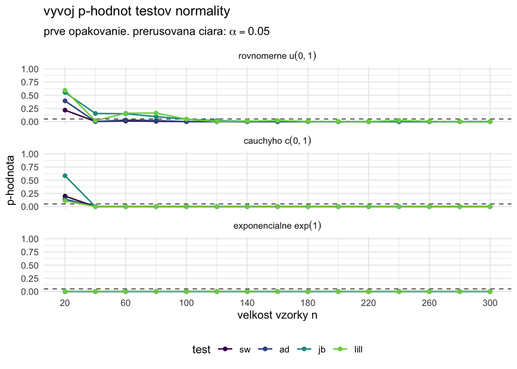

```r
graf_p <- ggplot(vysledky, aes(n, p, color = test, group = test)) +
  geom_hline(yintercept = alfa, linetype = 2, color = "grey40") +
  geom_line(linewidth = 0.65) + geom_point(size = 1.5) +
  facet_wrap(~ rozdelenie, ncol = 1, labeller = as_labeller(popisy_rozdeleni, default = label_parsed)) +
  scale_color_manual(values = farby, labels = popisy_testov) +
  scale_x_continuous(breaks = seq(20, 300, 40)) +
  scale_y_continuous(limits = c(0, 1)) +
  theme_minimal() + theme(legend.position = "bottom") +
  labs(title = TeX("vyvoj $p$-hodnot testov normality"),
       subtitle = TeX("prve opakovanie. prerusovana ciara: $\\alpha = 0.05$"),
       x = TeX("velkost vzorky $n$"), y = TeX("$p$-hodnota"), color = "test")
print(graf_p)
```

detail pri rozhodovacej hranici ponechava vsetky data a iba priblizuje zobrazenu cast osi.

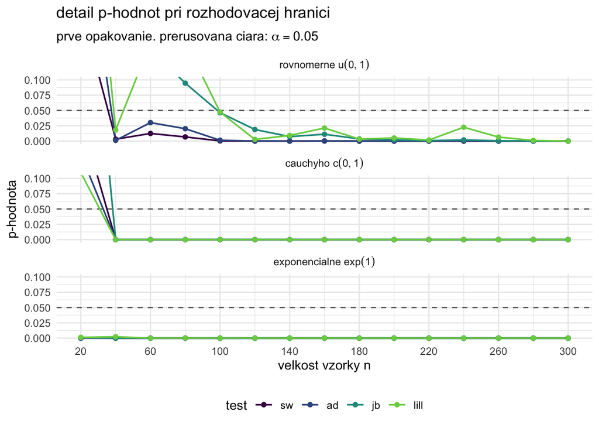

```r
graf_p_detail <- graf_p +
  coord_cartesian(ylim = c(0, 0.1)) +
  labs(title = TeX("detail $p$-hodnot pri rozhodovacej hranici"))
print(graf_p_detail)
```

jednotlive $p$-hodnoty nemusia s rastucim $n$ klesat, pretoze sa menia nahodne vzorky. pri rovnomernom rozdeleni v prvom priebehu sw a ad zamietaju od $n = 40$, jb a lill az od $n = 100$ pri vsetkych dalsich skumanych velkostiach. pri cauchyho rozdeleni takto vsetky testy zamietaju od $n = 40$, pri exponencialnom uz od $n = 20$.

# 5. sila testov a minimalna velkost vzorky

```r
sila_testov <- reshape(vysledky[c("rozdelenie", "n", "test", "sila")],
                       idvar = c("rozdelenie", "n"), timevar = "test", direction = "wide")
rownames(sila_testov) <- NULL
print(sila_testov, row.names = FALSE)
```

```
##     rozdelenie   n sila.sw sila.ad sila.jb sila.lill
##     rovnomerne  20   0.197   0.163   0.000     0.097
##     rovnomerne  40   0.592   0.436   0.000     0.174
##     rovnomerne  60   0.880   0.711   0.004     0.322
##     rovnomerne  80   0.968   0.865   0.165     0.495
##     rovnomerne 100   1.000   0.943   0.556     0.568
##     rovnomerne 120   1.000   0.971   0.847     0.693
##     rovnomerne 140   1.000   0.994   0.968     0.783
##     rovnomerne 160   1.000   0.998   0.994     0.875
##     rovnomerne 180   1.000   0.999   0.999     0.916
##     rovnomerne 200   1.000   1.000   1.000     0.947
##     rovnomerne 220   1.000   1.000   1.000     0.983
##     rovnomerne 240   1.000   1.000   1.000     0.984
##     rovnomerne 260   1.000   1.000   1.000     0.983
##     rovnomerne 280   1.000   1.000   1.000     0.993
##     rovnomerne 300   1.000   1.000   1.000     0.998
##       cauchyho  20   0.861   0.875   0.825     0.840
##       cauchyho  40   0.983   0.985   0.975     0.977
##       cauchyho  60   0.999   0.999   1.000     0.998
##       cauchyho  80   1.000   1.000   1.000     0.999
##       cauchyho 100   1.000   1.000   1.000     1.000
##       cauchyho 120   1.000   1.000   1.000     1.000
##       cauchyho 140   1.000   1.000   1.000     1.000
##       cauchyho 160   1.000   1.000   1.000     1.000
##       cauchyho 180   1.000   1.000   1.000     1.000
##       cauchyho 200   1.000   1.000   1.000     1.000
##       cauchyho 220   1.000   1.000   1.000     1.000
##       cauchyho 240   1.000   1.000   1.000     1.000
##       cauchyho 260   1.000   1.000   1.000     1.000
##       cauchyho 280   1.000   1.000   1.000     1.000
##       cauchyho 300   1.000   1.000   1.000     1.000
##  exponencialne  20   0.846   0.784   0.483     0.597
##  exponencialne  40   0.995   0.978   0.880     0.883
##  exponencialne  60   1.000   0.999   0.987     0.985
##  exponencialne  80   1.000   1.000   0.999     0.999
##  exponencialne 100   1.000   1.000   1.000     1.000
##  exponencialne 120   1.000   1.000   1.000     1.000
##  exponencialne 140   1.000   1.000   1.000     1.000
##  exponencialne 160   1.000   1.000   1.000     1.000
##  exponencialne 180   1.000   1.000   1.000     1.000
##  exponencialne 200   1.000   1.000   1.000     1.000
##  exponencialne 220   1.000   1.000   1.000     1.000
##  exponencialne 240   1.000   1.000   1.000     1.000
##  exponencialne 260   1.000   1.000   1.000     1.000
##  exponencialne 280   1.000   1.000   1.000     1.000
##  exponencialne 300   1.000   1.000   1.000     1.000
```

silu odhadujeme ako $\hat{\pi}(n) = \frac{1}{b}\sum_{r=1}^{b}\mathbf{1}\{p_r(n) < \alpha\}$. rozlisujeme dve hranice, aby sme odlisili jeden nahodny priebeh od opakovanych simulacii. $n_{\min,p} = \min\{n: p_1(m) < \alpha\ \forall m \geq n\}$ pouziva iba prve opakovanie, teda data z grafu $p$-hodnot. $n_{\min,95} = \min\{n: \hat{\pi}(m) \geq 0{,}95\ \forall m \geq n\}$ pouziva odhad sily zo vsetkych opakovani. v oboch definiciach $n,m \in \{20,40,\ldots,300\}$. ak hranicu nedosiahneme, zapiseme NA. v tabulke n_min_p oznacuje prvu hranicu a n_min_sila druhu. samotne zamietanie od urciteho $n$ v prvom priebehu nezarucuje 95-percentnu silu. ide o zvolene simulacne kriterium a empiricky odhad, nie o univerzalnu hranicu ani dokaz asymptotickej konzistentnosti.

```r
skupiny <- split(vysledky, list(vysledky$rozdelenie, vysledky$test), drop = TRUE)
n_min <- do.call(rbind, lapply(skupiny, function(data) {
  data <- data[order(data$n), ]
  splna_p <- vapply(seq_len(nrow(data)), function(i) {
    all(data$p[i:nrow(data)] < alfa)
  }, logical(1))
  splna_sila <- vapply(seq_len(nrow(data)), function(i) {
    all(data$sila[i:nrow(data)] >= ciel)
  }, logical(1))
  data.frame(rozdelenie = data$rozdelenie[1], test = data$test[1],
             n_min_p = if (any(splna_p)) min(data$n[splna_p]) else NA_integer_,
             n_min_sila = if (any(splna_sila)) min(data$n[splna_sila]) else NA_integer_)
}))
rownames(n_min) <- NULL
n_min <- n_min[order(n_min$rozdelenie, n_min$test), ]
print(n_min, row.names = FALSE)
```

```
##     rozdelenie test n_min_p n_min_sila
##     rovnomerne   sw      40         80
##     rovnomerne   ad      40        120
##     rovnomerne   jb     100        140
##     rovnomerne lill     100        220
##       cauchyho   sw      40         40
##       cauchyho   ad      40         40
##       cauchyho   jb      40         40
##       cauchyho lill      40         40
##  exponencialne   sw      20         40
##  exponencialne   ad      20         40
##  exponencialne   jb      20         60
##  exponencialne lill      20         60
```

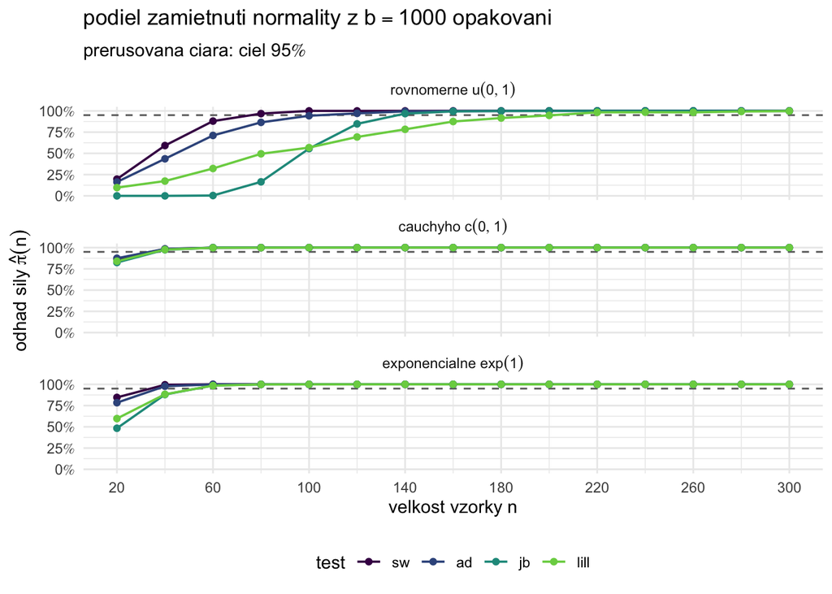

```r
graf_sily <- ggplot(vysledky, aes(n, sila, color = test, group = test)) +
  geom_hline(yintercept = ciel, linetype = 2, color = "grey40") +
  geom_line(linewidth = 0.65) + geom_point(size = 1.5) +
  facet_wrap(~ rozdelenie, ncol = 1, labeller = as_labeller(popisy_rozdeleni, default = label_parsed)) +
  scale_color_manual(values = farby, labels = popisy_testov) +
  scale_x_continuous(breaks = seq(20, 300, 40)) +
  scale_y_continuous(limits = c(0, 1), labels = function(x) TeX(paste0("$", 100 * x, "\\%$"))) +
  theme_minimal() + theme(legend.position = "bottom") +
  labs(title = TeX("podiel zamietnuti normality z $b = 1000$ opakovani"),
       subtitle = TeX("prerusovana ciara: ciel $95\\%$"),
       x = TeX("velkost vzorky $n$"), y = TeX("odhad sily $\\hat{\\pi}(n)$"), color = "test")
print(graf_sily)
```

# 6. zdovodnenie vysledkov

nasledujuce porovnanie testov pouziva hranicu $n_{\min,95}$ z opakovanych simulacii.

## rovnomerne rozdelenie

rozdelenie je symetricke, ale ohranicene a plochsie nez normalne, jeho sikmost je $0$ a spicatost $1{,}8$. sw dosiahne $n_{\min,95} = 80$, ad $120$, jb $140$ a lill $220$. sw teda v tejto simulacii odhali odlisny tvar najskor. jb sa pri malych vzorkach opiera iba o rozdiel spicatosti a lill reaguje na maximalnu odchylku distribucnych funkcii, preto tu potrebuju viac dat.

## cauchyho rozdelenie

rozdelenie je symetricke, ale ma velmi tazke chvosty. stredna hodnota, rozptyl ani populacna sikmost a spicatost neexistuju. extremne hodnoty vyrazne odlisuju vzorky od normality, vsetky styri testy dosiahnu $n_{\min,95} = 40$. vyberove momenty pre jb sa daju vypocitat, ale nemozno ich interpretovat ako odhady existujucich populacnych momentov.

## exponencialne rozdelenie

rozdelenie je pravostranne asymetricke so sikmostou $2$ a spicatostou $9$, preto sa od normalneho lisi tvarom aj pravym chvostom. sw a ad dosiahnu $n_{\min,95} = 40$, jb a lill $60$. sw a ad su pri malych vzorkach v tejto simulacii citlivejsie. jb pri vacsom $n$ spolahlivo zachyti odchylku sikmosti aj spicatosti, ad navyse zdoraznuje rozdiely v chvostoch.

# zaver

samotna symetria nezarucuje normalitu: cauchyho rozdelenie testy odhalia rychlo, rovnomerne potrebuje viac dat. sw ma najmensie alebo zhodne $n_{\min,95}$ vo vsetkych troch rozdeleniach, pri exponencialnom je rovnako rychly aj ad. uvedene hranice platia pre zvolene semeno, hladinu, pocet opakovani a skumanu mriezku. najmensia jednotliva $p$-hodnota neurcuje najsilnejsi test.